# DDK Modelling spatial variability

Add random smooths over trial.no per seg?

```r
summary(m7 <- bam(temp_var ~  s(trial.no) + segO + s(pace) + s(pace, by = groupO) + groupO + s(mean.speed2target) +  s(mean.speed2target, subj, bs = "fs", m=1, k = 4) + s(mean.speed2target, subj, by = segO, bs = "fs", m=1, k = 4) +  s(pace, subj, bs = "fs", m=1, k = 4) + s(pace, subj, by = segO, bs = "fs", m=1, k = 4) + s(trial.no, subj, bs = "fs", m=1, k = 4) + s(trial.no, subj, by = segO, bs = "fs", m=1, k = 4), data = df, family =Gamma(link=log), discrete = T, nthreads = 10))
```

```
##
## Family: Gamma
## Link function: log
##
## Formula:
## temp_var ~ s(trial.no) + segO + s(pace) + s(pace, by = groupO) +
##     groupO + s(mean.speed2target) + s(mean.speed2target, subj,
##     bs = "fs", m = 1, k = 4) + s(mean.speed2target, subj, by = segO,
##     bs = "fs", m = 1, k = 4) + s(pace, subj, bs = "fs", m = 1,
##     k = 4) + s(pace, subj, by = segO, bs = "fs", m = 1, k = 4) +
##     s(trial.no, subj, bs = "fs", m = 1, k = 4) + s(trial.no,
##     subj, by = segO, bs = "fs", m = 1, k = 4)
##
## Parametric coefficients:
##               Estimate Std. Error t value Pr(>|t|)
## (Intercept)    2.82548    0.07854  35.973   <2e-16 ***
## segOK         -0.18932    0.08043  -2.354   0.0193 *
## segOT         -0.10350    0.06981  -1.483   0.1394
## groupOtypical -0.26806    0.10893  -2.461   0.0145 *
## ---
## Signif. codes:  0 '***' 0.001 '**' 0.01 '*' 0.05 '.' 0.1 ' ' 1
##
## Approximate significance of smooth terms:
##                                       edf  Ref.df     F  p-value
## s(trial.no)                     1.497e+00   1.742 6.060 0.013166 *
## s(pace)                         2.230e+00   2.613 0.707 0.378208
## s(pace):groupOtypical           1.000e+00   1.000 6.470 0.011555 *
## s(mean.speed2target)            2.557e+00   2.968 8.061 4.22e-05 ***
## s(mean.speed2target,subj)       1.328e+01 159.000 0.108  < 2e-16 ***
## s(mean.speed2target,subj):segOK 1.648e+01 111.000 0.259 2.02e-06 ***
## s(mean.speed2target,subj):segOT 2.141e+01 132.000 0.333  < 2e-16 ***
## s(pace,subj)                    1.769e+01 159.000 0.155  < 2e-16 ***
## s(pace,subj):segOK              3.883e+00 116.000 0.038 0.000736 ***
## s(pace,subj):segOT              1.594e+00 125.000 0.013 0.000203 ***
## s(trial.no,subj)                3.637e+01 159.000 0.344 7.49e-07 ***
## s(trial.no,subj):segOK          3.072e-04 121.000 0.000 0.078823 .
## s(trial.no,subj):segOT          1.637e+01 132.000 0.164 0.000913 ***
## ---
## Signif. codes:  0 '***' 0.001 '**' 0.01 '*' 0.05 '.' 0.1 ' ' 1
##
## R-sq.(adj) =  0.665   Deviance explained = 79.6%
## fREML = 250.65  Scale est. = 0.10254   n = 397
```

Yes.

Plot:

```
## Summary:
##  * segO : factor; set to the value(s): P.
##  * groupO : factor; set to the value(s): typical.
##  * trial.no : numeric predictor; with 30 values ranging from 2.000000 to 12.000000.
##  * pace : numeric predictor; set to the value(s): 4.60358056265985.
##  * mean.speed2target : numeric predictor; set to the value(s): 0.0734671931042886.
##  * subj : factor; set to the value(s): CTRL01. (Might be canceled as random effect, check below.)
##  * NOTE : The following random effects columns are canceled: s(mean.speed2target,subj),s(mean.speed2target,subj):segOK,s(mean.speed2target,subj):segOT,s(pace,subj),s(pace,subj):segOK,s(pace,subj):segOT,s(trial.no,subj),s(trial.no,subj):segOK,s(trial.no,subj):segOT
##
```

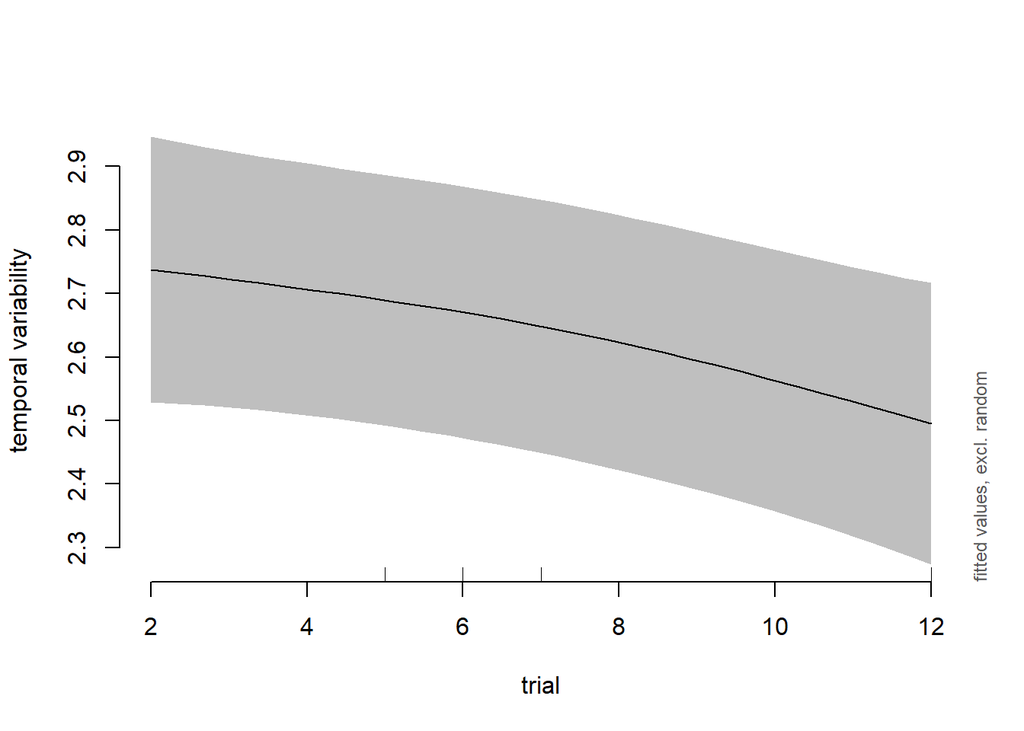

```r
plot_smooth(m7, view = "trial.no", ylab="temporal variability", xlab = "trial")
```

Separate for group?

```r
summary(m8 <- bam(temp_var ~  s(trial.no) + s(trial.no, by = groupO) + segO + s(pace) + s(pace, by = groupO) + groupO + s(mean.speed2target) +  s(mean.speed2target, subj, bs = "fs", m=1, k = 4) + s(mean.speed2target, subj, by = segO, bs = "fs", m=1, k = 4) +  s(pace, subj, bs = "fs", m=1, k = 4) + s(pace, subj, by = segO, bs = "fs", m=1, k = 4) + s(trial.no, subj, bs = "fs", m=1, k = 4) + s(trial.no, subj, by = segO, bs = "fs", m=1, k = 4), data = df, family =Gamma(link=log), discrete = T, nthreads = 10))
```

```
##
## Family: Gamma
## Link function: log
##
## Formula:
## temp_var ~ s(trial.no) + s(trial.no, by = groupO) + segO + s(pace) +
##     s(pace, by = groupO) + groupO + s(mean.speed2target) + s(mean.speed2target,
##     subj, bs = "fs", m = 1, k = 4) + s(mean.speed2target, subj,
##     by = segO, bs = "fs", m = 1, k = 4) + s(pace, subj, bs = "fs",
##     m = 1, k = 4) + s(pace, subj, by = segO, bs = "fs", m = 1,
##     k = 4) + s(trial.no, subj, bs = "fs", m = 1, k = 4) + s(trial.no,
##     subj, by = segO, bs = "fs", m = 1, k = 4)
##
## Parametric coefficients:
##               Estimate Std. Error t value Pr(>|t|)
## (Intercept)    2.82452    0.07854  35.964   <2e-16 ***
## segOK         -0.18877    0.08059  -2.343   0.0199 *
## segOT         -0.10200    0.06966  -1.464   0.1444
## groupOtypical -0.26486    0.10907  -2.428   0.0159 *
## ---
## Signif. codes:  0 '***' 0.001 '**' 0.01 '*' 0.05 '.' 0.1 ' ' 1
##
## Approximate significance of smooth terms:
##                                       edf  Ref.df     F  p-value
## s(trial.no)                     1.141e+00   1.218 3.470 0.071743 .
## s(trial.no):groupOtypical       1.496e+00   1.726 0.225 0.788327
## s(pace)                         2.220e+00   2.599 0.696 0.382735
## s(pace):groupOtypical           1.000e+00   1.000 6.280 0.012833 *
## s(mean.speed2target)            2.564e+00   2.975 8.002 4.42e-05 ***
## s(mean.speed2target,subj)       1.316e+01 159.000 0.107  < 2e-16 ***
## s(mean.speed2target,subj):segOK 1.620e+01 111.000 0.251 2.16e-06 ***
## s(mean.speed2target,subj):segOT 2.152e+01 132.000 0.338  < 2e-16 ***
## s(pace,subj)                    1.783e+01 159.000 0.157  < 2e-16 ***
## s(pace,subj):segOK              4.207e+00 116.000 0.041 0.000631 ***
## s(pace,subj):segOT              1.476e+00 125.000 0.012 0.000247 ***
## s(trial.no,subj)                3.684e+01 159.000 0.353 6.33e-07 ***
## s(trial.no,subj):segOK          2.597e-04 121.000 0.000 0.075653 .
## s(trial.no,subj):segOT          1.591e+01 132.000 0.158 0.001077 **
## ---
## Signif. codes:  0 '***' 0.001 '**' 0.01 '*' 0.05 '.' 0.1 ' ' 1
##
## R-sq.(adj) =  0.665   Deviance explained = 79.8%
## fREML =  252.6  Scale est. = 0.1025    n = 397
```

No.

Add block (first or second)?

```r
summary(m9 <- bam(temp_var ~  block + s(trial.no) + segO + s(pace) + s(pace, by = groupO) + groupO + s(mean.speed2target) +  s(mean.speed2target, subj, bs = "fs", m=1, k = 4) + s(mean.speed2target, subj, by = segO, bs = "fs", m=1, k = 4) +  s(pace, subj, bs = "fs", m=1, k = 4) + s(pace, subj, by = segO, bs = "fs", m=1, k = 4) + s(trial.no, subj, bs = "fs", m=1, k = 4) + s(trial.no, subj, by = segO, bs = "fs", m=1, k = 4), data = df, family =Gamma(link=log), discrete = T, nthreads = 10))
```

```
##
## Family: Gamma
## Link function: log
##
## Formula:
## temp_var ~ block + s(trial.no) + segO + s(pace) + s(pace, by = groupO) +
##     groupO + s(mean.speed2target) + s(mean.speed2target, subj,
##     bs = "fs", m = 1, k = 4) + s(mean.speed2target, subj, by = segO,
##     bs = "fs", m = 1, k = 4) + s(pace, subj, bs = "fs", m = 1,
##     k = 4) + s(pace, subj, by = segO, bs = "fs", m = 1, k = 4) +
##     s(trial.no, subj, bs = "fs", m = 1, k = 4) + s(trial.no,
##     subj, by = segO, bs = "fs", m = 1, k = 4)
##
## Parametric coefficients:
##                Estimate Std. Error t value Pr(>|t|)
## (Intercept)    2.827067   0.089360  31.637   <2e-16 ***
## blockDDK2     -0.002309   0.080706  -0.029   0.9772
## segOK         -0.189755   0.080661  -2.352   0.0194 *
## segOT         -0.103996   0.070049  -1.485   0.1389
## groupOtypical -0.268010   0.108987  -2.459   0.0146 *
## ---
## Signif. codes:  0 '***' 0.001 '**' 0.01 '*' 0.05 '.' 0.1 ' ' 1
##
## Approximate significance of smooth terms:
##                                       edf  Ref.df     F  p-value
## s(trial.no)                     1.534e+00   1.780 2.798 0.142473
## s(pace)                         2.222e+00   2.602 0.698 0.381736
## s(pace):groupOtypical           1.000e+00   1.000 6.406 0.011970 *
## s(mean.speed2target)            2.560e+00   2.972 8.049 4.23e-05 ***
## s(mean.speed2target,subj)       1.314e+01 159.000 0.106  < 2e-16 ***
## s(mean.speed2target,subj):segOK 1.636e+01 111.000 0.256 2.22e-06 ***
## s(mean.speed2target,subj):segOT 2.134e+01 132.000 0.331  < 2e-16 ***
## s(pace,subj)                    1.786e+01 159.000 0.157  < 2e-16 ***
## s(pace,subj):segOK              3.929e+00 116.000 0.038 0.000727 ***
## s(pace,subj):segOT              1.595e+00 125.000 0.013 0.000208 ***
## s(trial.no,subj)                3.630e+01 159.000 0.344 7.73e-07 ***
## s(trial.no,subj):segOK          2.914e-04 121.000 0.000 0.077615 .
## s(trial.no,subj):segOT          1.638e+01 132.000 0.164 0.000904 ***
## ---
## Signif. codes:  0 '***' 0.001 '**' 0.01 '*' 0.05 '.' 0.1 ' ' 1
##
## R-sq.(adj) =  0.665   Deviance explained = 79.7%
## fREML = 252.24  Scale est. = 0.10273   n = 397
```

No.

Per group?

```r
summary(m10 <- bam(temp_var ~  block + block:groupO + s(trial.no) + segO + s(pace) + s(pace, by = groupO) + groupO + s(mean.speed2target) +  s(mean.speed2target, subj, bs = "fs", m=1, k = 4) + s(mean.speed2target, subj, by = segO, bs = "fs", m=1, k = 4) +  s(pace, subj, bs = "fs", m=1, k = 4) + s(pace, subj, by = segO, bs = "fs", m=1, k = 4) + s(trial.no, subj, bs = "fs", m=1, k = 4) + s(trial.no, subj, by = segO, bs = "fs", m=1, k = 4), data = df, family =Gamma(link=log), discrete = T, nthreads = 10))
```

```
##
## Family: Gamma
## Link function: log
##
## Formula:
## temp_var ~ block + block:groupO + s(trial.no) + segO + s(pace) +
##     s(pace, by = groupO) + groupO + s(mean.speed2target) + s(mean.speed2target,
##     subj, bs = "fs", m = 1, k = 4) + s(mean.speed2target, subj,
##     by = segO, bs = "fs", m = 1, k = 4) + s(pace, subj, bs = "fs",
##     m = 1, k = 4) + s(pace, subj, by = segO, bs = "fs", m = 1,
##     k = 4) + s(trial.no, subj, bs = "fs", m = 1, k = 4) + s(trial.no,
##     subj, by = segO, bs = "fs", m = 1, k = 4)
##
## Parametric coefficients:
##                         Estimate Std. Error t value Pr(>|t|)
## (Intercept)              2.86507    0.09415  30.431  < 2e-16 ***
## blockDDK2               -0.07464    0.09703  -0.769  0.44246
## segOK                   -0.18535    0.08097  -2.289  0.02289 *
## segOT                   -0.10284    0.06986  -1.472  0.14225
## groupOtypical           -0.33476    0.12089  -2.769  0.00603 **
## blockDDK2:groupOtypical  0.12150    0.09534   1.274  0.20367
## ---
## Signif. codes:  0 '***' 0.001 '**' 0.01 '*' 0.05 '.' 0.1 ' ' 1
##
## Approximate significance of smooth terms:
##                                       edf  Ref.df     F  p-value
## s(trial.no)                     1.554e+00   1.802 2.633 0.155056
## s(pace)                         2.238e+00   2.617 0.697 0.382978
## s(pace):groupOtypical           1.000e+00   1.000 6.392 0.012072 *
## s(mean.speed2target)            2.532e+00   2.935 7.789 6.90e-05 ***
## s(mean.speed2target,subj)       1.328e+01 159.000 0.107  < 2e-16 ***
## s(mean.speed2target,subj):segOK 1.637e+01 111.000 0.255 1.44e-06 ***
## s(mean.speed2target,subj):segOT 2.148e+01 132.000 0.337  < 2e-16 ***
## s(pace,subj)                    1.851e+01 159.000 0.164  < 2e-16 ***
## s(pace,subj):segOK              4.436e+00 116.000 0.044 0.000487 ***
## s(pace,subj):segOT              1.520e+00 124.000 0.013 0.000205 ***
## s(trial.no,subj)                3.734e+01 159.000 0.360 1.14e-06 ***
## s(trial.no,subj):segOK          2.289e-04 121.000 0.000 0.069414 .
## s(trial.no,subj):segOT          1.649e+01 132.000 0.166 0.000801 ***
## ---
## Signif. codes:  0 '***' 0.001 '**' 0.01 '*' 0.05 '.' 0.1 ' ' 1
##
## R-sq.(adj) =  0.671   Deviance explained = 80.3%
## fREML = 253.02  Scale est. = 0.10092   n = 397
```

No, so we can take block out.

Add gender?

```r
summary(m11 <- bam(temp_var ~  gender + s(trial.no) + segO + s(pace) + s(pace, by = groupO) + groupO + s(mean.speed2target) +  s(mean.speed2target, subj, bs = "fs", m=1, k = 4) + s(mean.speed2target, subj, by = segO, bs = "fs", m=1, k = 4) +  s(pace, subj, bs = "fs", m=1, k = 4) + s(pace, subj, by = segO, bs = "fs", m=1, k = 4) + s(trial.no, subj, bs = "fs", m=1, k = 4) + s(trial.no, subj, by = segO, bs = "fs", m=1, k = 4), data = df, family =Gamma(link=log), discrete = T, nthreads = 10))
```

```
##
## Family: Gamma
## Link function: log
##
## Formula:
## temp_var ~ gender + s(trial.no) + segO + s(pace) + s(pace, by = groupO) +
##     groupO + s(mean.speed2target) + s(mean.speed2target, subj,
##     bs = "fs", m = 1, k = 4) + s(mean.speed2target, subj, by = segO,
##     bs = "fs", m = 1, k = 4) + s(pace, subj, bs = "fs", m = 1,
##     k = 4) + s(pace, subj, by = segO, bs = "fs", m = 1, k = 4) +
##     s(trial.no, subj, bs = "fs", m = 1, k = 4) + s(trial.no,
##     subj, by = segO, bs = "fs", m = 1, k = 4)
##
## Parametric coefficients:
##                 Estimate Std. Error t value Pr(>|t|)
## (Intercept)    2.8254955  0.1210815  23.335   <2e-16 ***
## genderM       -0.0001108  0.1187173  -0.001   0.9993
## segOK         -0.1880760  0.0806365  -2.332   0.0204 *
## segOT         -0.1024240  0.0699246  -1.465   0.1442
## groupOtypical -0.2691284  0.1104551  -2.437   0.0155 *
## ---
## Signif. codes:  0 '***' 0.001 '**' 0.01 '*' 0.05 '.' 0.1 ' ' 1
##
## Approximate significance of smooth terms:
##                                       edf  Ref.df     F  p-value
## s(trial.no)                     1.497e+00   1.741 6.058 0.013224 *
## s(pace)                         2.231e+00   2.614 0.693 0.384282
## s(pace):groupOtypical           1.000e+00   1.000 6.424 0.011848 *
## s(mean.speed2target)            2.552e+00   2.963 7.935 5.07e-05 ***
## s(mean.speed2target,subj)       1.310e+01 158.000 0.107  < 2e-16 ***
## s(mean.speed2target,subj):segOK 1.647e+01 111.000 0.258 2.17e-06 ***
## s(mean.speed2target,subj):segOT 2.139e+01 132.000 0.332  < 2e-16 ***
## s(pace,subj)                    1.745e+01 158.000 0.154  < 2e-16 ***
## s(pace,subj):segOK              3.900e+00 116.000 0.038 0.000745 ***
## s(pace,subj):segOT              1.595e+00 125.000 0.013 0.000214 ***
## s(trial.no,subj)                3.621e+01 158.000 0.345 7.94e-07 ***
## s(trial.no,subj):segOK          3.078e-04 121.000 0.000 0.079257 .
## s(trial.no,subj):segOT          1.642e+01 132.000 0.164 0.000904 ***
## ---
## Signif. codes:  0 '***' 0.001 '**' 0.01 '*' 0.05 '.' 0.1 ' ' 1
##
## R-sq.(adj) =  0.666   Deviance explained = 79.7%
## fREML = 251.88  Scale est. = 0.10242   n = 397
```

No.

Per group?

```r
summary(m12 <- bam(temp_var ~  gender + gender:groupO + s(trial.no) + segO + s(pace) + s(pace, by = groupO) + groupO + s(mean.speed2target) +  s(mean.speed2target, subj, bs = "fs", m=1, k = 4) + s(mean.speed2target, subj, by = segO, bs = "fs", m=1, k = 4) +  s(pace, subj, bs = "fs", m=1, k = 4) + s(pace, subj, by = segO, bs = "fs", m=1, k = 4) + s(trial.no, subj, bs = "fs", m=1, k = 4) + s(trial.no, subj, by = segO, bs = "fs", m=1, k = 4), data = df, family =Gamma(link=log), discrete = T, nthreads = 10))
```

```
##
## Family: Gamma
## Link function: log
##
## Formula:
## temp_var ~ gender + gender:groupO + s(trial.no) + segO + s(pace) +
##     s(pace, by = groupO) + groupO + s(mean.speed2target) + s(mean.speed2target,
##     subj, bs = "fs", m = 1, k = 4) + s(mean.speed2target, subj,
##     by = segO, bs = "fs", m = 1, k = 4) + s(pace, subj, bs = "fs",
##     m = 1, k = 4) + s(pace, subj, by = segO, bs = "fs", m = 1,
##     k = 4) + s(trial.no, subj, bs = "fs", m = 1, k = 4) + s(trial.no,
##     subj, by = segO, bs = "fs", m = 1, k = 4)
##
## Parametric coefficients:
##                       Estimate Std. Error t value Pr(>|t|)
## (Intercept)            2.84488    0.16261  17.495   <2e-16 ***
## genderM               -0.02548    0.18360  -0.139   0.8897
## segOK                 -0.18721    0.08085  -2.315   0.0214 *
## segOT                 -0.10171    0.07003  -1.452   0.1476
## groupOtypical         -0.30317    0.21154  -1.433   0.1530
## genderM:groupOtypical  0.04473    0.24250   0.184   0.8538
## ---
## Signif. codes:  0 '***' 0.001 '**' 0.01 '*' 0.05 '.' 0.1 ' ' 1
##
## Approximate significance of smooth terms:
##                                       edf  Ref.df     F  p-value
## s(trial.no)                     1.495e+00   1.740 6.066 0.013200 *
## s(pace)                         2.243e+00   2.629 0.684 0.388832
## s(pace):groupOtypical           1.000e+00   1.000 6.396 0.012037 *
## s(mean.speed2target)            2.549e+00   2.958 7.830 5.90e-05 ***
## s(mean.speed2target,subj)       1.299e+01 157.000 0.107  < 2e-16 ***
## s(mean.speed2target,subj):segOK 1.643e+01 111.000 0.257 2.18e-06 ***
## s(mean.speed2target,subj):segOT 2.146e+01 132.000 0.334  < 2e-16 ***
## s(pace,subj)                    1.714e+01 157.000 0.152  < 2e-16 ***
## s(pace,subj):segOK              3.983e+00 116.000 0.039 0.000725 ***
## s(pace,subj):segOT              1.562e+00 125.000 0.013 0.000230 ***
## s(trial.no,subj)                3.602e+01 157.000 0.346 8.37e-07 ***
## s(trial.no,subj):segOK          3.217e-04 121.000 0.000 0.080318 .
## s(trial.no,subj):segOT          1.648e+01 132.000 0.165 0.000885 ***
## ---
## Signif. codes:  0 '***' 0.001 '**' 0.01 '*' 0.05 '.' 0.1 ' ' 1
##
## R-sq.(adj) =  0.667   Deviance explained = 79.8%
## fREML = 252.38  Scale est. = 0.10227   n = 397
```

No difference.

Age?

```r
summary(m13 <- bam(temp_var ~  s(age) + s(trial.no) + segO + s(pace) + s(pace, by = groupO) + groupO + s(mean.speed2target) +  s(mean.speed2target, subj, bs = "fs", m=1, k = 4) + s(mean.speed2target, subj, by = segO, bs = "fs", m=1, k = 4) +  s(pace, subj, bs = "fs", m=1, k = 4) + s(pace, subj, by = segO, bs = "fs", m=1, k = 4) + s(trial.no, subj, bs = "fs", m=1, k = 4) + s(trial.no, subj, by = segO, bs = "fs", m=1, k = 4), data = df, family =Gamma(link=log), discrete = T, nthreads = 10))
```

```
##
## Family: Gamma
## Link function: log
##
## Formula:
## temp_var ~ s(age) + s(trial.no) + segO + s(pace) + s(pace, by = groupO) +
##     groupO + s(mean.speed2target) + s(mean.speed2target, subj,
##     bs = "fs", m = 1, k = 4) + s(mean.speed2target, subj, by = segO,
##     bs = "fs", m = 1, k = 4) + s(pace, subj, bs = "fs", m = 1,
##     k = 4) + s(pace, subj, by = segO, bs = "fs", m = 1, k = 4) +
##     s(trial.no, subj, bs = "fs", m = 1, k = 4) + s(trial.no,
##     subj, by = segO, bs = "fs", m = 1, k = 4)
##
## Parametric coefficients:
##               Estimate Std. Error t value Pr(>|t|)
## (Intercept)    2.82844    0.07928  35.678   <2e-16 ***
## segOK         -0.19223    0.08080  -2.379   0.0181 *
## segOT         -0.10458    0.07010  -1.492   0.1370
## groupOtypical -0.27163    0.10959  -2.479   0.0138 *
## ---
## Signif. codes:  0 '***' 0.001 '**' 0.01 '*' 0.05 '.' 0.1 ' ' 1
##
## Approximate significance of smooth terms:
##                                       edf  Ref.df     F  p-value
## s(age)                          1.000e+00   1.000 0.396 0.529544
## s(trial.no)                     1.517e+00   1.770 6.010 0.012879 *
## s(pace)                         2.223e+00   2.607 0.713 0.375372
## s(pace):groupOtypical           1.000e+00   1.000 6.252 0.013024 *
## s(mean.speed2target)            2.541e+00   2.948 8.107 4.34e-05 ***
## s(mean.speed2target,subj)       1.322e+01 158.000 0.108  < 2e-16 ***
## s(mean.speed2target,subj):segOK 1.693e+01 111.000 0.272 1.87e-06 ***
## s(mean.speed2target,subj):segOT 2.127e+01 132.000 0.327  < 2e-16 ***
## s(pace,subj)                    1.710e+01 158.000 0.150  < 2e-16 ***
## s(pace,subj):segOK              3.286e+00 116.000 0.031 0.000955 ***
## s(pace,subj):segOT              1.681e+00 124.000 0.014 0.000200 ***
## s(trial.no,subj)                3.617e+01 158.000 0.345 8.59e-07 ***
## s(trial.no,subj):segOK          3.815e-04 121.000 0.000 0.084494 .
## s(trial.no,subj):segOT          1.591e+01 132.000 0.157 0.001061 **
## ---
## Signif. codes:  0 '***' 0.001 '**' 0.01 '*' 0.05 '.' 0.1 ' ' 1
##
## R-sq.(adj) =  0.665   Deviance explained = 79.5%
## fREML = 252.35  Scale est. = 0.10286   n = 397
```

No.

Per group?

```r
summary(m14 <- bam(temp_var ~  s(age) + s(age, by = groupO) + s(trial.no) + segO + s(pace) + s(pace, by = groupO) + groupO + s(mean.speed2target) +  s(mean.speed2target, subj, bs = "fs", m=1, k = 4) + s(mean.speed2target, subj, by = segO, bs = "fs", m=1, k = 4) +  s(pace, subj, bs = "fs", m=1, k = 4) + s(pace, subj, by = segO, bs = "fs", m=1, k = 4) + s(trial.no, subj, bs = "fs", m=1, k = 4) + s(trial.no, subj, by = segO, bs = "fs", m=1, k = 4), data = df, family =Gamma(link=log), discrete = T, nthreads = 10))
```

```
##
## Family: Gamma
## Link function: log
##
## Formula:
## temp_var ~ s(age) + s(age, by = groupO) + s(trial.no) + segO +
##     s(pace) + s(pace, by = groupO) + groupO + s(mean.speed2target) +
##     s(mean.speed2target, subj, bs = "fs", m = 1, k = 4) + s(mean.speed2target,
##     subj, by = segO, bs = "fs", m = 1, k = 4) + s(pace, subj,
##     bs = "fs", m = 1, k = 4) + s(pace, subj, by = segO, bs = "fs",
##     m = 1, k = 4) + s(trial.no, subj, bs = "fs", m = 1, k = 4) +
##     s(trial.no, subj, by = segO, bs = "fs", m = 1, k = 4)
##
## Parametric coefficients:
##               Estimate Std. Error t value Pr(>|t|)
## (Intercept)    2.83118    0.07929  35.707   <2e-16 ***
## segOK         -0.19521    0.08091  -2.413   0.0165 *
## segOT         -0.10455    0.06986  -1.497   0.1357
## groupOtypical -0.27531    0.10924  -2.520   0.0123 *
## ---
## Signif. codes:  0 '***' 0.001 '**' 0.01 '*' 0.05 '.' 0.1 ' ' 1
##
## Approximate significance of smooth terms:
##                                       edf  Ref.df     F  p-value
## s(age)                          1.000e+00   1.000 1.467 0.226905
## s(age):groupOtypical            1.000e+00   1.000 1.175 0.279370
## s(trial.no)                     1.528e+00   1.784 5.733 0.015300 *
## s(pace)                         2.145e+00   2.513 0.621 0.419988
## s(pace):groupOtypical           1.000e+00   1.000 6.655 0.010443 *
## s(mean.speed2target)            2.559e+00   2.968 8.185 3.61e-05 ***
## s(mean.speed2target,subj)       1.319e+01 157.000 0.108  < 2e-16 ***
## s(mean.speed2target,subj):segOK 1.704e+01 109.000 0.280 1.40e-06 ***
## s(mean.speed2target,subj):segOT 2.096e+01 132.000 0.319  < 2e-16 ***
## s(pace,subj)                    1.690e+01 157.000 0.149  < 2e-16 ***
## s(pace,subj):segOK              3.398e+00 115.000 0.033 0.000883 ***
## s(pace,subj):segOT              1.651e+00 124.000 0.014 0.000216 ***
## s(trial.no,subj)                3.617e+01 157.000 0.349 8.67e-07 ***
## s(trial.no,subj):segOK          4.555e-04 121.000 0.000 0.090648 .
## s(trial.no,subj):segOT          1.599e+01 132.000 0.159 0.001045 **
## ---
## Signif. codes:  0 '***' 0.001 '**' 0.01 '*' 0.05 '.' 0.1 ' ' 1
##
## R-sq.(adj) =  0.666   Deviance explained = 79.6%
## fREML = 252.91  Scale est. = 0.10255   n = 397
```

No.

# 7 Final model

Final model, fit with fREML:

```r
mFinalExpl <- m7
```

## 7.1 Check assumptions

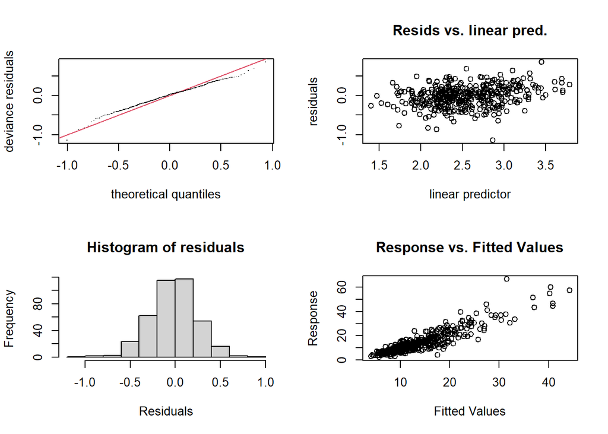

[output not shown]

[output cut: 95 more lines]

```
##
##                                       k'      edf k-index p-value
## s(trial.no)                     9.00e+00 1.50e+00    1.00    0.50
## s(pace)                         9.00e+00 2.23e+00    1.05    0.86
## s(pace):groupOtypical           9.00e+00 1.00e+00    1.05    0.86
## s(mean.speed2target)            9.00e+00 2.56e+00    1.00    0.61
## s(mean.speed2target,subj)       1.68e+02 1.33e+01    1.00    0.57
## s(mean.speed2target,subj):segOK 1.68e+02 1.65e+01    1.00    0.61
## s(mean.speed2target,subj):segOT 1.68e+02 2.14e+01    1.00    0.58
## s(pace,subj)                    1.68e+02 1.77e+01    1.05    0.86
## s(pace,subj):segOK              1.68e+02 3.88e+00    1.05    0.81
## s(pace,subj):segOT              1.68e+02 1.59e+00    1.05    0.84
## s(trial.no,subj)                1.68e+02 3.64e+01    1.00    0.53
## s(trial.no,subj):segOK          1.68e+02 3.07e-04    1.00    0.58
## s(trial.no,subj):segOT          1.68e+02 1.64e+01    1.00    0.50
```

```r
gam.check(mFinalExpl)
```

Looks reasonable.

Model criticism, trim model:

```r
df2 <- df[abs(scale(resid(mFinalExpl))) < 2.5, ] # trim model
(1 - (nrow(df2))/nrow(df)) * 100
```

```
## [1] 1.511335
```

We throw out 1.51% of the data.

Fit using trimmed data:

```r
summary(m7trim <- bam(temp_var ~  s(trial.no) + segO + s(pace) + s(pace, by = groupO) + groupO + s(mean.speed2target) + s(trial.no, subj, bs = "fs", m=1, k = 4) + s(trial.no, subj, by = segO, bs = "fs", m=1, k = 4) +  s(pace, subj, bs = "fs", m=1, k = 4) + s(pace, subj, by = segO, bs = "fs", m=1, k = 4) + s(mean.speed2target, subj, bs = "fs", m=1, k = 4) + s(mean.speed2target, subj, by = segO, bs = "fs", m=1, k = 4), data = df2, family =Gamma(link=log), discrete = T, nthreads = 10))
```

```
##
## Family: Gamma
## Link function: log
##
## Formula:
## temp_var ~ s(trial.no) + segO + s(pace) + s(pace, by = groupO) +
##     groupO + s(mean.speed2target) + s(trial.no, subj, bs = "fs",
##     m = 1, k = 4) + s(trial.no, subj, by = segO, bs = "fs", m = 1,
##     k = 4) + s(pace, subj, bs = "fs", m = 1, k = 4) + s(pace,
##     subj, by = segO, bs = "fs", m = 1, k = 4) + s(mean.speed2target,
##     subj, bs = "fs", m = 1, k = 4) + s(mean.speed2target, subj,
##     by = segO, bs = "fs", m = 1, k = 4)
##
## Parametric coefficients:
##               Estimate Std. Error t value Pr(>|t|)
## (Intercept)    2.84657    0.07750  36.728  < 2e-16 ***
## segOK         -0.21029    0.07628  -2.757  0.00628 **
## segOT         -0.15525    0.06340  -2.449  0.01504 *
## groupOtypical -0.26994    0.10612  -2.544  0.01159 *
## ---
## Signif. codes:  0 '***' 0.001 '**' 0.01 '*' 0.05 '.' 0.1 ' ' 1
##
## Approximate significance of smooth terms:
##                                    edf  Ref.df     F  p-value
## s(trial.no)                      1.688   1.979 4.760  0.01384 *
## s(pace)                          2.644   3.080 1.627  0.21064
## s(pace):groupOtypical            1.000   1.000 5.463  0.02024 *
## s(mean.speed2target)             2.813   3.254 9.380 4.20e-06 ***
## s(trial.no,subj)                34.170 159.000 0.317  < 2e-16 ***
## s(trial.no,subj):segOK           8.418 120.000 0.085  0.01018 *
## s(trial.no,subj):segOT          12.255 130.000 0.122  0.00230 **
## s(pace,subj)                    24.909 159.000 0.250  < 2e-16 ***
## s(pace,subj):segOK               4.235 114.000 0.042  0.00020 ***
## s(pace,subj):segOT               1.561 125.000 0.013  0.00209 **
## s(mean.speed2target,subj)       15.731 159.000 0.130  < 2e-16 ***
## s(mean.speed2target,subj):segOK 14.534 108.000 0.223 7.81e-07 ***
## s(mean.speed2target,subj):segOT 20.364 129.000 0.326  < 2e-16 ***
## ---
## Signif. codes:  0 '***' 0.001 '**' 0.01 '*' 0.05 '.' 0.1 ' ' 1
##
## R-sq.(adj) =  0.727   Deviance explained = 83.4%
## fREML = 218.79  Scale est. = 0.084903  n = 391
```

Comparable.

Check assumptions:

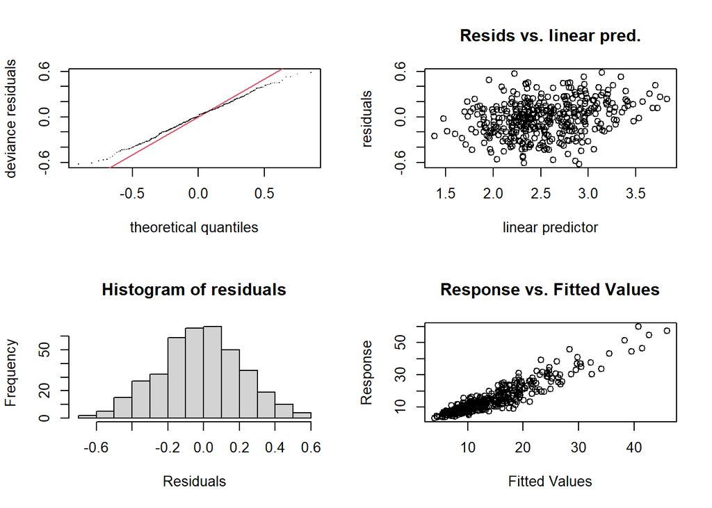

[output not shown]

[output cut: 95 more lines]

```
##
##                                     k'    edf k-index p-value
## s(trial.no)                       9.00   1.69    0.98    0.44
## s(pace)                           9.00   2.64    1.05    0.82
## s(pace):groupOtypical             9.00   1.00    1.05    0.82
## s(mean.speed2target)              9.00   2.81    0.96    0.28
## s(trial.no,subj)                168.00  34.17    0.98    0.40
## s(trial.no,subj):segOK          168.00   8.42    0.98    0.31
## s(trial.no,subj):segOT          168.00  12.26    0.98    0.33
## s(pace,subj)                    168.00  24.91    1.05    0.84
## s(pace,subj):segOK              168.00   4.23    1.05    0.83
## s(pace,subj):segOT              168.00   1.56    1.05    0.88
## s(mean.speed2target,subj)       168.00  15.73    0.96    0.22
## s(mean.speed2target,subj):segOK 168.00  14.53    0.96    0.25
## s(mean.speed2target,subj):segOT 168.00  20.36    0.96    0.21
```

```r
gam.check(m7trim)
```

Looks allright.

## 7.2 Final Plots

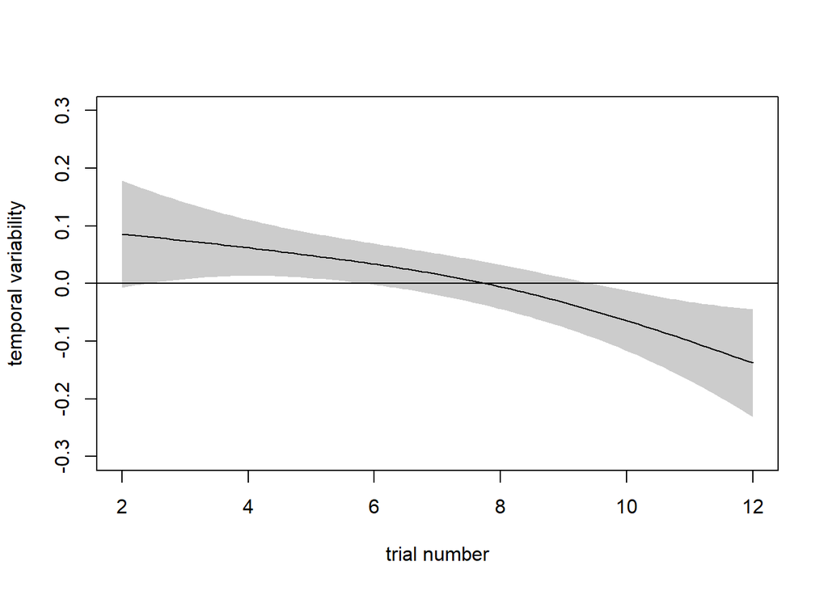

```r
plot(m7trim, select = 1, shade = T, rug= F, xlab = "trial number", ylab = "temporal variability", ylim = c(-0.3,0.3))
abline(h=0)
```

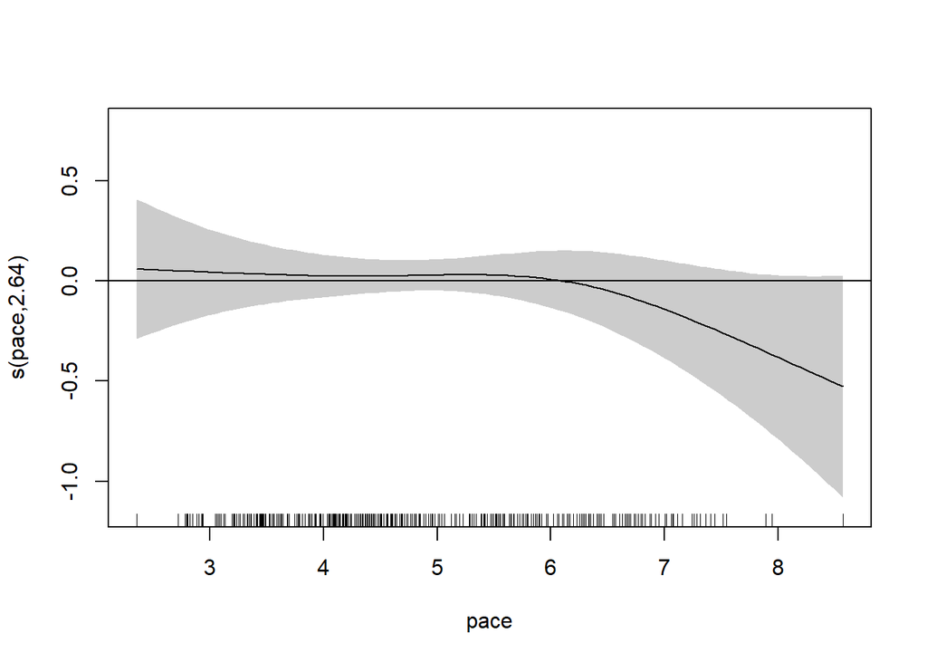

```r
plot(m7trim, select = 2, shade = T)
abline(h=0)
```

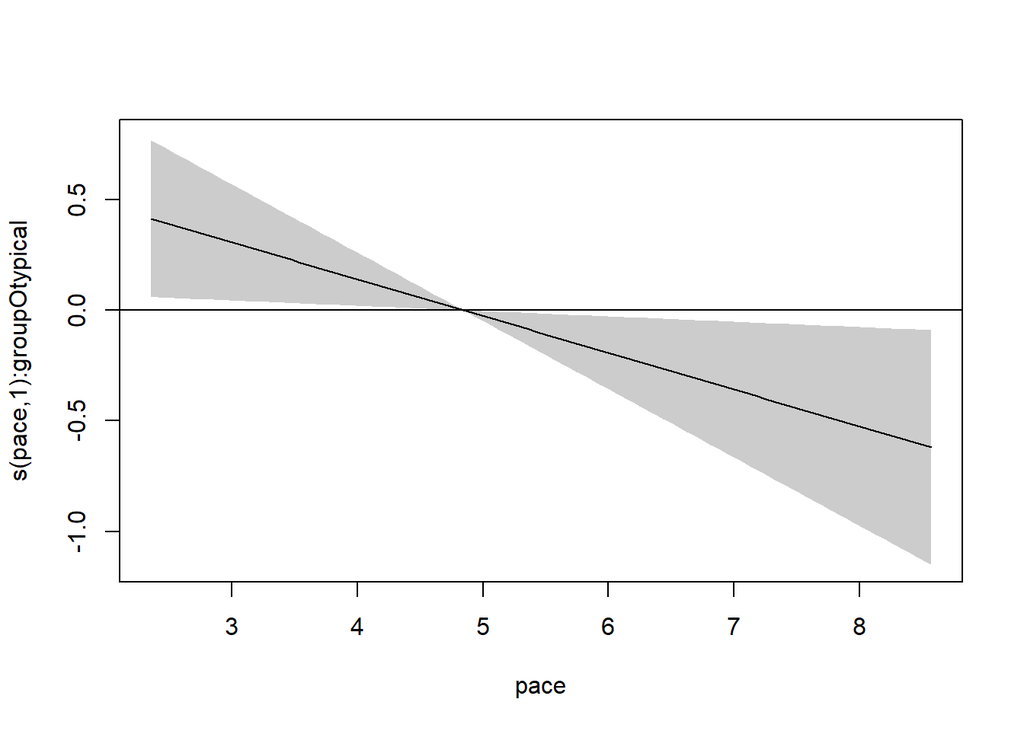

```r
plot(m7trim, select = 3, shade = T, rug= F)
abline(h=0)
```

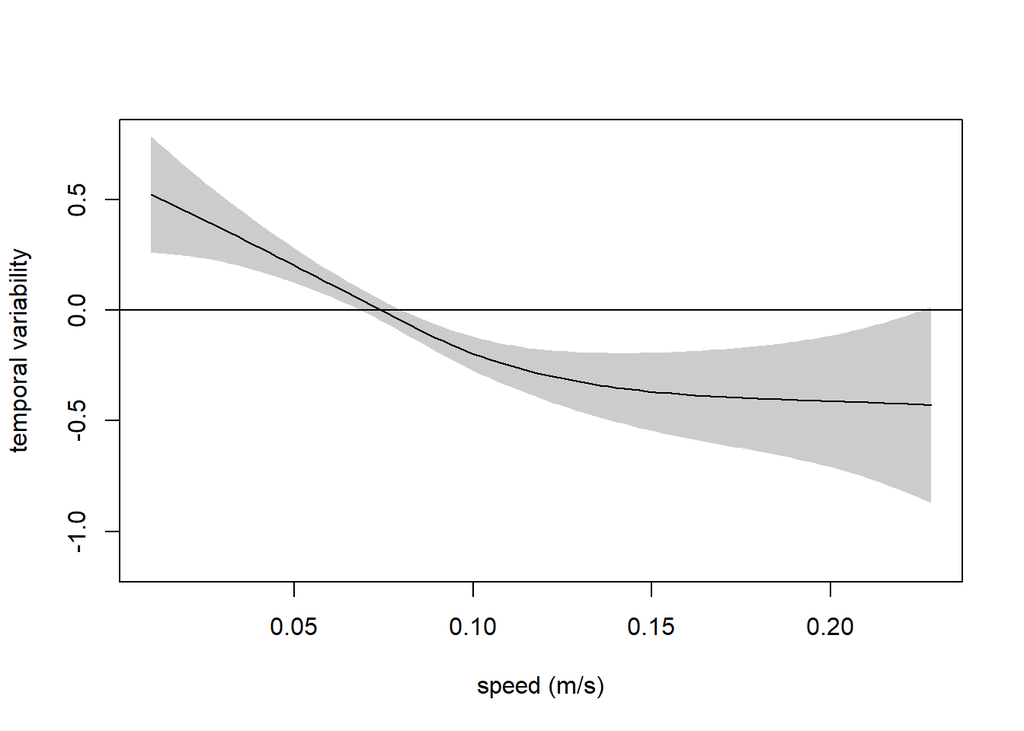

```r
plot(m7trim, select = 4, shade = T, rug= F, xlab = "speed (m/s)", ylab = "temporal variability")
abline(h=0)
```

```
## Summary:
##  * segO : factor; set to the value(s): P.
##  * groupO : factor; set to the value(s): PD, typical.
##  * trial.no : numeric predictor; set to the value(s): 7.
##  * pace : numeric predictor; with 30 values ranging from 2.352941 to 8.571429.
##  * mean.speed2target : numeric predictor; set to the value(s): 0.0734671931042886.
##  * subj : factor; set to the value(s): CTRL01. (Might be canceled as random effect, check below.)
##  * NOTE : The following random effects columns are canceled: s(trial.no,subj),s(trial.no,subj):segOK,s(trial.no,subj):segOT,s(pace,subj),s(pace,subj):segOK,s(pace,subj):segOT,s(mean.speed2target,subj),s(mean.speed2target,subj):segOK,s(mean.speed2target,subj):segOT
##
```

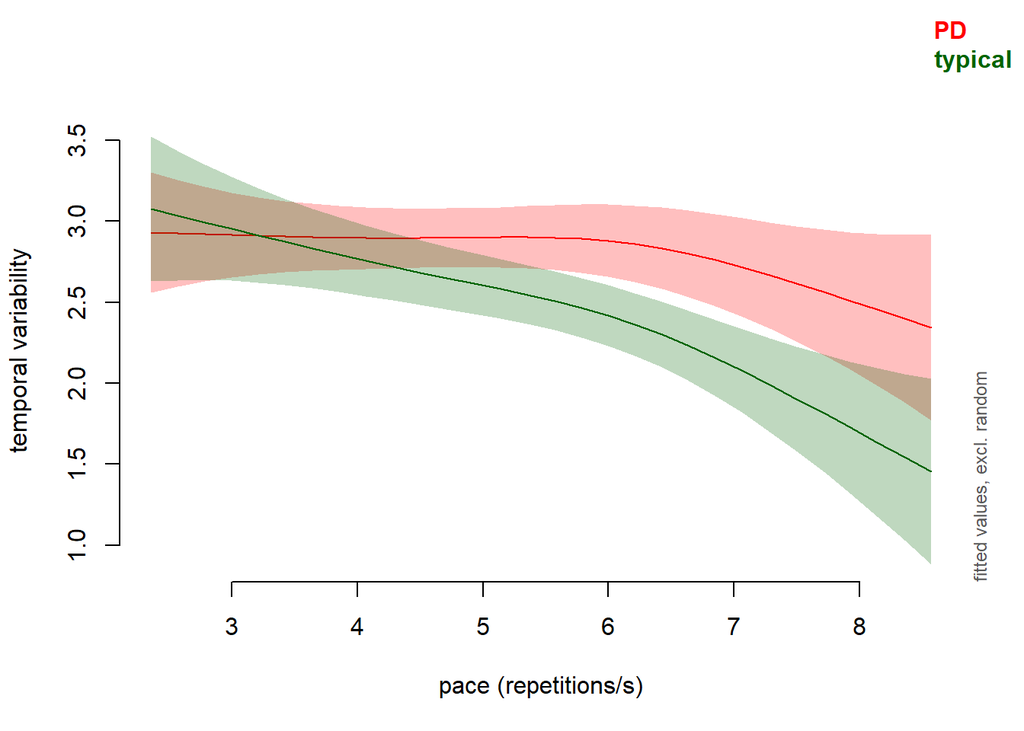

```r
plot_smooth(m7trim, view="pace", plot_all="groupO", rm.ranef=TRUE, col=c("red", "darkgreen"), ylab = "temporal variability",  xlab = "pace (repetitions/s)", rug = F)
```

Latex table function:

```r
gamtabs2 <- function (model, caption = " ", label = "tab.gam",
    pnames = NA, snames = NA, ptab = NA, stab = NA, ...)
{
    if (!requireNamespace("xtable", quietly = TRUE)) {
        stop("Package 'xtable' needed for this function to work. Please install it.",
            call. = FALSE)
    }
    sum.gam <- model
    if (!inherits(model, "summary.gam")) {
        sum.gam <- summary(model)
    }
    if (is.na(ptab[1])) {
        ptab = as.data.frame(sum.gam$p.table, stringsAsFactors = FALSE)
    }
    if (is.na(stab[1])) {
        stab = as.data.frame(sum.gam$s.table, stringsAsFactors = FALSE)
    }
    if (!is.na(pnames[1])) {
        rownames(ptab) = pnames
    }
    if (!is.na(snames[1])) {
        rownames(stab) = snames
    }
    colnames(ptab)[4] = "p-value"
    colnames(ptab)[3] = "t-value"
    ptab.cnames = colnames(ptab)
    stab.cnames = colnames(stab)
    stab.cnames[3] = "F-value"
    colnames(ptab) = c("A", "B", "C", "D")
    if (ncol(stab) != 0) {
        colnames(stab) = colnames(ptab)
    }
    tab = rbind(ptab, stab)
    colnames(tab) = ptab.cnames
    tab = round(tab, 4)
    m = data.frame(matrix(0, nrow(tab), ncol(tab)), stringsAsFactors = FALSE)
    for (i in 1:nrow(tab)) {
        for (j in 1:4) {
            if ((j == 4) & (tab[i, j] < 1e-03)) {
                m[i, j] = "< 0.001"
            }
            else {
                m[i, j] = sprintf("%3.3f", tab[i, j])
            }
        }
    }
    colnames(m) = colnames(tab)
    rownames(m) = rownames(tab)
    tab = m
    tab2 = rbind(c(ptab.cnames), tab[1:nrow(ptab), ])
    if (nrow(stab) > 0) {
        tab2 = rbind(tab2, c(stab.cnames), tab[(nrow(ptab) +
            1):nrow(tab), ])
    }
    if (nrow(stab)) {
        rownames(tab2)[(nrow(ptab) + 2)] = "B. smooth terms"
    }
    rownames(tab2)[1] = "A. parametric coefficients"
    for (i in 1:nrow(tab2)) {
        if (tab2[i, 4] == "0")
            tab2[i, 4] = "< 0.0001"
        if (length(grep("\\.", tab2[i, 2])) == 0)
            tab2[i, 2] = paste(tab2[i, 2], ".0000", sep = "")
    }
    print(xtable::xtable(tab2, caption = caption, label = label,
        align = "lrrrr"), include.colnames = FALSE, hline.after = c(0,
        (nrow(ptab) + 1), nrow(tab2)), ...)
}
```

Latex table:

```r
options(xtable.comment = FALSE)
gamtabs2(m7trim)
```

```
## \begin{table}[ht]
## \centering
## \begin{tabular}{lrrrr}
##    \hline
## A. parametric coefficients & Estimate & Std. Error & t-value & p-value \\
##   (Intercept) & 2.847 & 0.077 & 36.728 & $<$ 0.001 \\
##   segOK & -0.210 & 0.076 & -2.757 & 0.006 \\
##   segOT & -0.155 & 0.063 & -2.449 & 0.015 \\
##   groupOtypical & -0.270 & 0.106 & -2.544 & 0.012 \\
##    \hline
## B. smooth terms & edf & Ref.df & F-value & p-value \\
##   s(trial.no) & 1.688 & 1.979 & 4.760 & 0.014 \\
##   s(pace) & 2.643 & 3.080 & 1.627 & 0.211 \\
##   s(pace):groupOtypical & 1.000 & 1.000 & 5.463 & 0.020 \\
##   s(mean.speed2target) & 2.813 & 3.254 & 9.380 & $<$ 0.001 \\
##   s(trial.no,subj) & 34.170 & 159.000 & 0.316 & $<$ 0.001 \\
##   s(trial.no,subj):segOK & 8.418 & 120.000 & 0.085 & 0.010 \\
##   s(trial.no,subj):segOT & 12.255 & 130.000 & 0.122 & 0.002 \\
##   s(pace,subj) & 24.909 & 159.000 & 0.250 & $<$ 0.001 \\
##   s(pace,subj):segOK & 4.235 & 114.000 & 0.042 & $<$ 0.001 \\
##   s(pace,subj):segOT & 1.562 & 125.000 & 0.013 & 0.002 \\
##   s(mean.speed2target,subj) & 15.731 & 159.000 & 0.130 & $<$ 0.001 \\
##   s(mean.speed2target,subj):segOK & 14.534 & 108.000 & 0.223 & $<$ 0.001 \\
##   s(mean.speed2target,subj):segOT & 20.364 & 129.000 & 0.326 & $<$ 0.001 \\
##    \hline
## \end{tabular}
## \caption{ }
## \label{tab.gam}
## \end{table}
```

# 8 PD severity

## 8.1 PD only

Subset data to contain only PD:

```r
dfPD <- subset(df, group == "PD")
```

Add years since diagnosis?

```r
summary(mPD1 <- bam(temp_var ~  s(diagnosis) + s(trial.no) + segO + s(pace) + s(mean.speed2target) +  s(mean.speed2target, subj, bs = "fs", m=1, k = 4) + s(mean.speed2target, subj, by = segO, bs = "fs", m=1, k = 4) +  s(pace, subj, bs = "fs", m=1, k = 4) + s(pace, subj, by = segO, bs = "fs", m=1, k = 4) + s(trial.no, subj, bs = "fs", m=1, k = 4) + s(trial.no, subj, by = segO, bs = "fs", m=1, k = 4), data = dfPD, family =Gamma(link=log), discrete = T, nthreads = 10))
```

```
##
## Family: Gamma
## Link function: log
##
## Formula:
## temp_var ~ s(diagnosis) + s(trial.no) + segO + s(pace) + s(mean.speed2target) +
##     s(mean.speed2target, subj, bs = "fs", m = 1, k = 4) + s(mean.speed2target,
##     subj, by = segO, bs = "fs", m = 1, k = 4) + s(pace, subj,
##     bs = "fs", m = 1, k = 4) + s(pace, subj, by = segO, bs = "fs",
##     m = 1, k = 4) + s(trial.no, subj, bs = "fs", m = 1, k = 4) +
##     s(trial.no, subj, by = segO, bs = "fs", m = 1, k = 4)
##
## Parametric coefficients:
##             Estimate Std. Error t value Pr(>|t|)
## (Intercept)  2.89574    0.08696  33.298   <2e-16 ***
## segOK       -0.24867    0.11430  -2.176   0.0317 *
## segOT       -0.13181    0.10996  -1.199   0.2331
## ---
## Signif. codes:  0 '***' 0.001 '**' 0.01 '*' 0.05 '.' 0.1 ' ' 1
##
## Approximate significance of smooth terms:
##                                       edf Ref.df      F  p-value
## s(diagnosis)                    1.732e+00  1.812  1.142 0.409382
## s(trial.no)                     1.000e+00  1.000  3.163 0.078033 .
## s(pace)                         2.296e+00  2.673  1.018 0.262153
## s(mean.speed2target)            1.000e+00  1.000 15.344 0.000154 ***
## s(mean.speed2target,subj)       3.278e+00 69.000  0.060 4.93e-07 ***
## s(mean.speed2target,subj):segOK 2.156e-04 54.000  0.000 0.018160 *
## s(mean.speed2target,subj):segOT 1.245e+01 56.000  0.619 3.28e-06 ***
## s(pace,subj)                    6.718e+00 71.000  0.126 2.55e-05 ***
## s(pace,subj):segOK              9.088e+00 52.000  0.376 0.000375 ***
## s(pace,subj):segOT              4.426e-01 55.000  0.008 0.017451 *
## s(trial.no,subj)                1.246e+01 71.000  0.240 0.001265 **
## s(trial.no,subj):segOK          5.736e+00 56.000  0.135 0.041868 *
## s(trial.no,subj):segOT          6.055e+00 58.000  0.142 0.018956 *
## ---
## Signif. codes:  0 '***' 0.001 '**' 0.01 '*' 0.05 '.' 0.1 ' ' 1
##
## R-sq.(adj) =  0.583   Deviance explained = 74.6%
## fREML = 129.66  Scale est. = 0.11647   n = 178
```

No.

UPDRS total score?

```r
summary(mPD2 <- bam(temp_var ~  s(total_UPDRS) + s(trial.no) + segO + s(pace) + s(mean.speed2target) +  s(mean.speed2target, subj, bs = "fs", m=1, k = 4) + s(mean.speed2target, subj, by = segO, bs = "fs", m=1, k = 4) +  s(pace, subj, bs = "fs", m=1, k = 4) + s(pace, subj, by = segO, bs = "fs", m=1, k = 4) + s(trial.no, subj, bs = "fs", m=1, k = 4) + s(trial.no, subj, by = segO, bs = "fs", m=1, k = 4), data = dfPD, family =Gamma(link=log), discrete = T, nthreads = 10))
```

```
##
## Family: Gamma
## Link function: log
##
## Formula:
## temp_var ~ s(total_UPDRS) + s(trial.no) + segO + s(pace) + s(mean.speed2target) +
##     s(mean.speed2target, subj, bs = "fs", m = 1, k = 4) + s(mean.speed2target,
##     subj, by = segO, bs = "fs", m = 1, k = 4) + s(pace, subj,
##     bs = "fs", m = 1, k = 4) + s(pace, subj, by = segO, bs = "fs",
##     m = 1, k = 4) + s(trial.no, subj, bs = "fs", m = 1, k = 4) +
##     s(trial.no, subj, by = segO, bs = "fs", m = 1, k = 4)
##
## Parametric coefficients:
##             Estimate Std. Error t value Pr(>|t|)
## (Intercept)   2.9223     0.0879  33.245   <2e-16 ***
## segOK        -0.2648     0.1160  -2.282   0.0244 *
## segOT        -0.1551     0.1120  -1.385   0.1689
## ---
## Signif. codes:  0 '***' 0.001 '**' 0.01 '*' 0.05 '.' 0.1 ' ' 1
##
## Approximate significance of smooth terms:
##                                       edf Ref.df      F  p-value
## s(total_UPDRS)                  1.000e+00   1.00  0.142 0.706909
## s(trial.no)                     1.000e+00   1.00  3.002 0.085951 .
## s(pace)                         2.131e+00   2.46  1.050 0.264266
## s(mean.speed2target)            1.000e+00   1.00 15.411 0.000151 ***
## s(mean.speed2target,subj)       3.382e+00  69.00  0.062  < 2e-16 ***
## s(mean.speed2target,subj):segOK 1.595e-04  54.00  0.000 0.016470 *
## s(mean.speed2target,subj):segOT 1.162e+01  56.00  0.534 3.58e-06 ***
## s(pace,subj)                    8.749e+00  71.00  0.180 1.52e-05 ***
## s(pace,subj):segOK              9.209e+00  52.00  0.406 0.000134 ***
## s(pace,subj):segOT              1.790e+00  54.00  0.037 0.008668 **
## s(trial.no,subj)                1.247e+01  71.00  0.239 0.000990 ***
## s(trial.no,subj):segOK          5.991e+00  56.00  0.143 0.035900 *
## s(trial.no,subj):segOT          6.042e+00  58.00  0.141 0.017176 *
## ---
## Signif. codes:  0 '***' 0.001 '**' 0.01 '*' 0.05 '.' 0.1 ' ' 1
##
## R-sq.(adj) =  0.594   Deviance explained = 75.6%
## fREML = 130.25  Scale est. = 0.11432   n = 178
```

No.

UPDRS motor score?

```r
summary(mPD3 <- bam(temp_var ~   s(motor_UPDRS) + s(trial.no) + segO + s(pace) + s(mean.speed2target) +  s(mean.speed2target, subj, bs = "fs", m=1, k = 4) + s(mean.speed2target, subj, by = segO, bs = "fs", m=1, k = 4) +  s(pace, subj, bs = "fs", m=1, k = 4) + s(pace, subj, by = segO, bs = "fs", m=1, k = 4) + s(trial.no, subj, bs = "fs", m=1, k = 4) + s(trial.no, subj, by = segO, bs = "fs", m=1, k = 4), data = dfPD, family =Gamma(link=log), discrete = T, nthreads = 10))
```

```
##
## Family: Gamma
## Link function: log
##
## Formula:
## temp_var ~ s(motor_UPDRS) + s(trial.no) + segO + s(pace) + s(mean.speed2target) +
##     s(mean.speed2target, subj, bs = "fs", m = 1, k = 4) + s(mean.speed2target,
##     subj, by = segO, bs = "fs", m = 1, k = 4) + s(pace, subj,
##     bs = "fs", m = 1, k = 4) + s(pace, subj, by = segO, bs = "fs",
##     m = 1, k = 4) + s(trial.no, subj, bs = "fs", m = 1, k = 4) +
##     s(trial.no, subj, by = segO, bs = "fs", m = 1, k = 4)
##
## Parametric coefficients:
##             Estimate Std. Error t value Pr(>|t|)
## (Intercept)  2.91328    0.08808  33.074   <2e-16 ***
## segOK       -0.26021    0.11611  -2.241    0.027 *
## segOT       -0.15231    0.11241  -1.355    0.178
## ---
## Signif. codes:  0 '***' 0.001 '**' 0.01 '*' 0.05 '.' 0.1 ' ' 1
##
## Approximate significance of smooth terms:
##                                       edf Ref.df      F  p-value
## s(motor_UPDRS)                  1.000e+00  1.000  0.522 0.471645
## s(trial.no)                     1.000e+00  1.000  2.961 0.088110 .
## s(pace)                         2.040e+00  2.343  1.009 0.288622
## s(mean.speed2target)            1.000e+00  1.000 14.449 0.000238 ***
## s(mean.speed2target,subj)       3.221e+00 70.000  0.058  < 2e-16 ***
## s(mean.speed2target,subj):segOK 7.705e-05 54.000  0.000 0.019184 *
## s(mean.speed2target,subj):segOT 1.106e+01 56.000  0.484 4.47e-06 ***
## s(pace,subj)                    9.676e+00 71.000  0.208 1.28e-05 ***
## s(pace,subj):segOK              9.037e+00 52.000  0.393 0.000141 ***
## s(pace,subj):segOT              2.363e+00 54.000  0.051 0.005991 **
## s(trial.no,subj)                1.243e+01 71.000  0.239 0.001022 **
## s(trial.no,subj):segOK          6.394e+00 56.000  0.156 0.029892 *
## s(trial.no,subj):segOT          6.463e+00 58.000  0.154 0.013424 *
## ---
## Signif. codes:  0 '***' 0.001 '**' 0.01 '*' 0.05 '.' 0.1 ' ' 1
##
## R-sq.(adj) =  0.602   Deviance explained = 76.2%
## fREML = 129.87  Scale est. = 0.11254   n = 178
```

No.

Tremor score?

```r
summary(mPD4 <- bam(temp_var ~   s(tremor, k = 6) + s(trial.no) + segO + s(pace) + s(mean.speed2target) +  s(mean.speed2target, subj, bs = "fs", m=1, k = 4) + s(mean.speed2target, subj, by = segO, bs = "fs", m=1, k = 4) +  s(pace, subj, bs = "fs", m=1, k = 4) + s(pace, subj, by = segO, bs = "fs", m=1, k = 4) + s(trial.no, subj, bs = "fs", m=1, k = 4) + s(trial.no, subj, by = segO, bs = "fs", m=1, k = 4), data = dfPD, family =Gamma(link=log), discrete = T, nthreads = 10))
```

```
##
## Family: Gamma
## Link function: log
##
## Formula:
## temp_var ~ s(tremor, k = 6) + s(trial.no) + segO + s(pace) +
##     s(mean.speed2target) + s(mean.speed2target, subj, bs = "fs",
##     m = 1, k = 4) + s(mean.speed2target, subj, by = segO, bs = "fs",
##     m = 1, k = 4) + s(pace, subj, bs = "fs", m = 1, k = 4) +
##     s(pace, subj, by = segO, bs = "fs", m = 1, k = 4) + s(trial.no,
##     subj, bs = "fs", m = 1, k = 4) + s(trial.no, subj, by = segO,
##     bs = "fs", m = 1, k = 4)
##
## Parametric coefficients:
##             Estimate Std. Error t value Pr(>|t|)
## (Intercept)  2.89853    0.09775  29.652   <2e-16 ***
## segOK       -0.26613    0.11381  -2.338   0.0211 *
## segOT       -0.15320    0.11126  -1.377   0.1713
## ---
## Signif. codes:  0 '***' 0.001 '**' 0.01 '*' 0.05 '.' 0.1 ' ' 1
##
## Approximate significance of smooth terms:
##                                       edf Ref.df      F  p-value
## s(tremor)                       1.000e+00  1.000  0.875 0.351604
## s(trial.no)                     1.000e+00  1.000  2.721 0.101866
## s(pace)                         2.096e+00  2.413  0.805 0.349924
## s(mean.speed2target)            1.000e+00  1.000 18.960 3.03e-05 ***
## s(mean.speed2target,subj)       3.030e+00 70.000  0.054 5.33e-07 ***
## s(mean.speed2target,subj):segOK 4.523e-05 54.000  0.000 0.021941 *
## s(mean.speed2target,subj):segOT 1.147e+01 56.000  0.519 4.29e-06 ***
## s(pace,subj)                    1.020e+01 71.000  0.228 1.23e-05 ***
## s(pace,subj):segOK              8.857e+00 52.000  0.363 0.000287 ***
## s(pace,subj):segOT              1.718e+00 54.000  0.035 0.009050 **
## s(trial.no,subj)                1.267e+01 71.000  0.248 0.001329 **
## s(trial.no,subj):segOK          4.831e+00 56.000  0.109 0.052668 .
## s(trial.no,subj):segOT          5.709e+00 58.000  0.131 0.020144 *
## ---
## Signif. codes:  0 '***' 0.001 '**' 0.01 '*' 0.05 '.' 0.1 ' ' 1
##
## R-sq.(adj) =  0.591   Deviance explained = 75.3%
## fREML = 129.73  Scale est. = 0.1153    n = 178
```

No.